# Statistical Learning Project

In this project i've decided to analyze the cars sold on Craigslist, an American website that provides a wide variety of Services, including the reselling of used cars

## Exploratory Analysis

```r
head(Cars)
```

|  | price | year | manufacturer | make | condition | cylinders | fuel | odometer | title_status | transmission | drive | type | paint_color | weather |
| --- | --- | --- | --- | --- | --- | --- | --- | --- | --- | --- | --- | --- | --- | --- |
| 1 | 11900 | 2010 | dodge | challenger se | good | 6 cylinders | gas | 43600 | clean | automatic | rwd | coupe | red | 38 |
| 4 | 2800 | 2004 | ford | taurus | good | 6 cylinders | gas | 168591 | clean | automatic | fwd | sedan | grey | 47 |
| 5 | 400 | 2001 |  | 2001 Grand Prix |  |  | gas | 217000 | clean | automatic |  |  |  | 47 |
| 6 | 9900 | 2007 | gmc | yukon | good | 8 cylinders | gas | 169000 | clean | automatic | 4wd |  |  | 38 |
| 7 | 12500 | 2015 | jeep | patriot high altitude | like new | 4 cylinders | gas | 39500 | rebuilt | automatic | 4wd | SUV | grey | 38 |
| 8 | 3900 | 2008 | bmw | 3 series |  |  | gas | 0 | clean |  |  |  |  | 48 |

### A Note on empty fields

[output not shown]

As a first step we can look at the heatmap of correlations for the numerical data to get a quicker idea of what to expect from those values

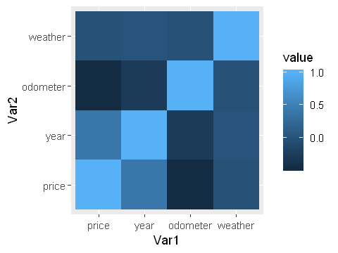

```r
cols <- unlist(lapply(Cars, is.numeric))
cormat <- round(cor(Cars[,cols]),3)
melted_cormat <- melt(cormat)
ggplot(data = melted_cormat, aes(x=Var1, y=Var2, fill=value)) + geom_tile()
```

#### Price

```r
summary(Cars$price)
```

```
   Min. 1st Qu.  Median    Mean 3rd Qu.    Max.
      1    4000    8500   11510   16100   49998
```

Regarding prices there is not much expectation a part from some data possibly normally distributed with maybe some skewness to the right due to what we've seen earlier

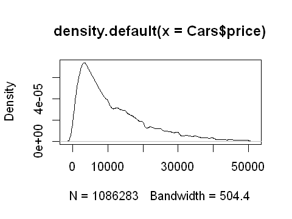

```r
den <- density(Cars$price)
plot(den)
```

#### Year

```r
summary(Cars$year)
```

```
   Min. 1st Qu.  Median    Mean 3rd Qu.    Max.
   1900    2004    2008    2007    2013    2019
```

As for the year of the car already by looking at the summary we can see a strong presence of new cars being sold.

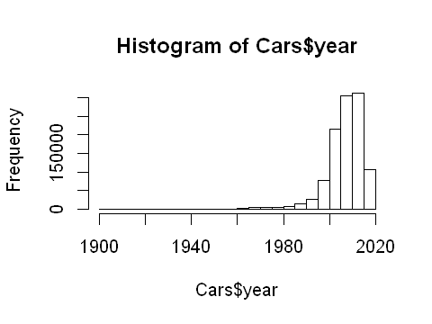

```r
hist(Cars$year)
```

#### Condition

```r
summary(Cars$condition)
```

**1**

355763

**excellent**

333869

**fair**

43406

**good**

273447

**like new**

73208

**new**

3495

**salvage**

3095

As for the conditions of the car we see the first really interesting categorical variable. Just by the look of the distribution we can foresee a possible relationship between conditions and prices.

In addition to that I've decided not to ignore the fact taht almost a third of cars didn't have a condition in their description. This could be of some importance since we are evaluating what determines the price of the car on a e-commerce website

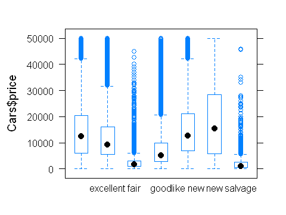

```r
bwplot(Cars$price~Cars$condition)
```

As expected the cars in better conditions show a greater mean in prices

#### Odometer

```r
summary(Cars$odometer)
```

```
   Min. 1st Qu.  Median    Mean 3rd Qu.    Max.
      0   60000  107502  108469  151000  296078
```

Odometer is surely both an interesting and simple variable since we'd expect to have a negative correlation between the number of miles run and the price of the car

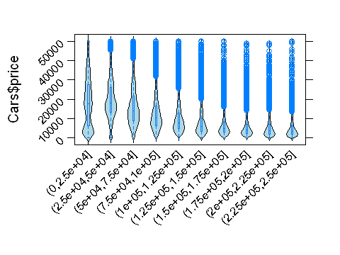

```r
bwplot(Cars$price~cut(Cars$odometer, breaks = seq(0,250000,by=25000)), scales=list(y=list(rot=45), x=list(rot=45)),panel = function(..., box.ratio) {
 panel.violin(..., col = "lightblue",
 varwidth = FALSE, box.ratio = box.ratio)
 panel.bwplot(..., col='black',
 cex=0.8, pch='|', fill='gray', box.ratio = .1)
 })
```

```r
cor(Cars$price,Cars$odometer)
```

-0.477865383332237

#### Drive

```r
summary(Cars$drive)
```

**1**

270055

**4wd**

345590

**fwd**

297921

**rwd**

172717

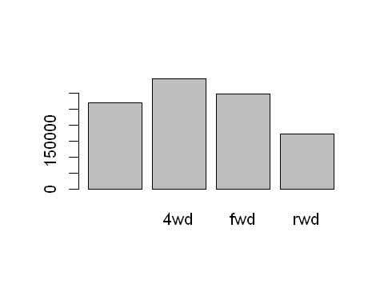

```r
plot(Cars$drive)
```

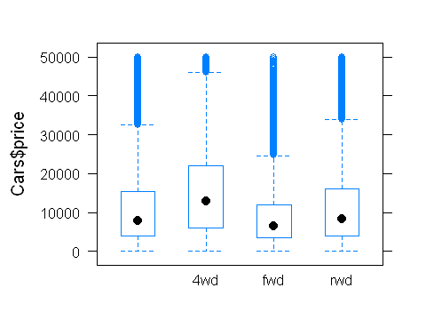

```r
bwplot(Cars$price~Cars$drive)
```

By analyzing the cost related to the type of drive an interesting behavior appears. Rear wheel drive cars cost more than forward wheel drive cars. If we make the assumption that rwd cars are in general older than fwd cars this goes againts the assumption we made earlier about the correlation between price and year. This may be due to the fact that rwd cars are considered vintage in most cases, therefore cost more.

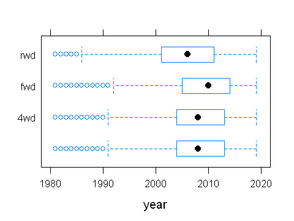

```r
bwplot(drive~year, data=Cars[Cars$year>1980,])
```

This boxplot confirms our hypotesis that rwd cars are in general older than fwd cars.

## Model Data

#### Year

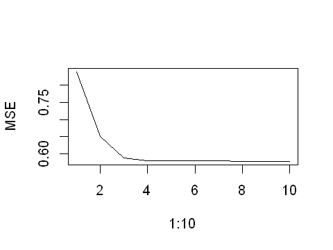

```r
MSE <- c()
for(i in 1:10){
  lm.fit <- lm(price~poly(year, degree=i), data=Test)
  y.pred <- predict(lm.fit, newdata=Validate)
  mse <- mean((Validate$price-y.pred)^2)
  MSE <-  c(MSE, mse)
}
plot(1:10,MSE,type="l")
```

#### Odometer

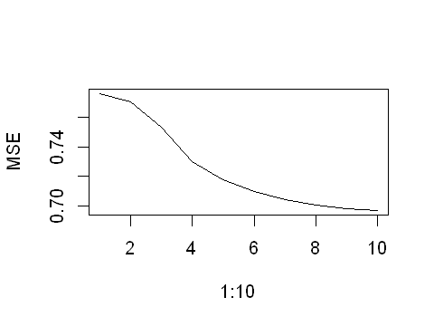

```r
MSE <- c()
for(i in 1:10){
  lm.fit <- lm(price~poly(odometer, degree=i), data=Test)
  y.pred <- predict(lm.fit, newdata=Validate)
  mse <- mean((Validate$price-y.pred)^2)
  MSE <-  c(MSE, mse)
}
plot(1:10,MSE,type="l")
```

### Linear Model

At first i've tried to model a simple linear model with the following regressors:

- year
- manufacturer
- condition
- cylinder
- fuel
- odometer
- title_status
- transmission
- drive
- type
- paint_color

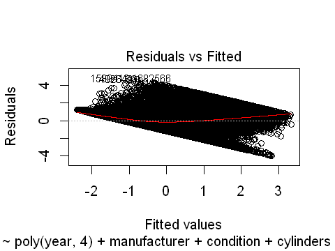

```r
plot(lm.out.poly,which=1)
```

#### MSE

```r
y.pred <- predict(lm.out,newdata=Validate,type='response')
y.pred.poly <- predict(lm.out.poly,newdata=Validate,type='response')
mse <- mean((Validate$price-y.pred)^2)
mse.poly <- mean((Validate$price-y.pred.poly)^2)
mse
mse.poly
```

0.43607556923731

0.313518366518053

### Lasso and Ridge regression

Lasso and Ridge regression are some of the simpler techniques to reduce model complexity and prevent over-fitting which may result from simple linear regression.

In ridge regression, the cost function is altered by adding a penalty equivalent to square of the magnitude of the coefficients.

Lasso regression not only helps in reducing over-fitting but it can help us in feature selection.

##### Ridge

```r
ridge.mod <- glmnet(x.poly[train,], y[train], alpha = 0)
cv.out <- cv.glmnet(x.poly[train,], y[train], alpha = 0)
bestlam <- cv.out$lambda.min
ridge.pred <- predict(ridge.mod, s = bestlam, newx = x.poly[test,])
mean((ridge.pred-ytest)^2)
```

0.31208608055591

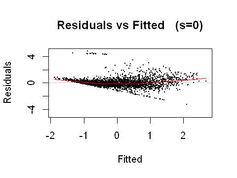

```r
plotres(ridge.mod,which=3)
```

##### Lasso

```r
ridge.mod <- glmnet(x.poly, y, alpha = 1)
ridge.mod <- glmnet(x.poly[train,], y[train], alpha = 1)
cv.out <- cv.glmnet(x.poly[train,], y[train], alpha = 1)
bestlam <- cv.out$lambda.min
ridge.pred <- predict(ridge.mod, s = bestlam, newx = x.poly[test,])
mean((ridge.pred-ytest)^2)
```

0.311079242122699

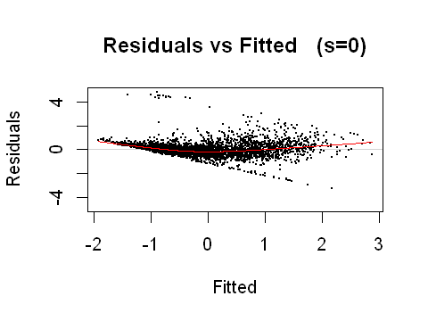

```r
plotres(ridge.mod,which=3)
```

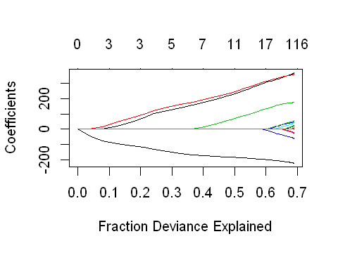

```r
plot(ridge.mod,'dev',label=TRUE)
```

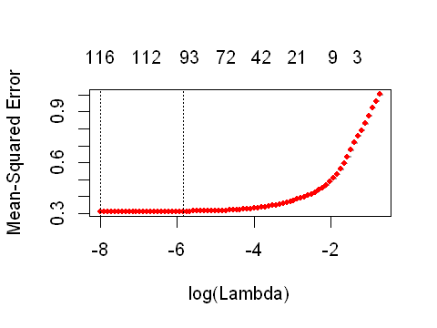

```r
plot(cv.out)
```

```r
coef.cv.out <- coef(cv.out)
coef.cv.out@Dimnames[[1]][which(coef.cv.out == 0 ) ]
```

1. 'manufactureralfa'

2. 'manufactureralfa-romeo'

3. 'manufacturerchev'

4. 'manufacturerchevrolet'

5. 'manufacturerdatsun'

6. 'manufacturerharley'

7. 'manufacturerhennessey'

8. 'manufacturerinfinity'

9. 'manufacturerland rover'

10. 'manufacturerlandrover'

11. 'manufacturermercedesbenz'

12. 'manufacturermorgan'

13. 'manufacturernoble'

14. 'manufacturerpontiac'

15. 'manufacturerporche'

16. 'manufacturervolvo'

17. 'conditionlike new'

18. 'transmissionautomatic'

19. 'typebus'

20. 'typeother'

21. 'typeSUV'

22. 'typevan'

23. 'paint_colorbrown'

24. 'paint_colorgreen'

25. 'paint_colorgrey'

26. 'paint_colorpurple'

27. 'paint_colorred'

28. 'paint_colorsilver'

##### Reduced Lasso

```r
ridge.mod <- glmnet(x.poly.redu, y, alpha = 1)
ridge.mod <- glmnet(x.poly.redu[train,], y[train], alpha = 1)
cv.out <- cv.glmnet(x.poly.redu[train,], y[train], alpha = 1)
bestlam <- cv.out$lambda.min
ridge.pred <- predict(ridge.mod, s = bestlam, newx = x.poly.redu[test,])
mean((ridge.pred-ytest)^2)
```

0.38890237802162

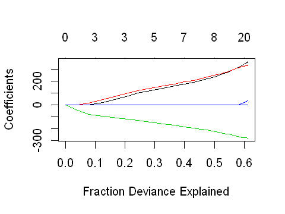

```r
plot(ridge.mod,'dev',label=TRUE)
```

## Final Notes

This was an interesting dataset to takle, however its multidimensionality and its large number of features forced me to focus my attention in a particular direction ignoring some features that in my opinion where not interesting in the "grand scheme". Nonetheless it could be a fun challenge to try and include those dimensions and maybe drop some other aspects to obtain a different perspective on the problem and even maybe a better prediction model.